# Exercise 4

Group Members: Xiaoyu Ji, Mengtong Guo, Yingchan Chu

### 1 Constructing the matrix X

```python
import numpy as np
import matplotlib.pyplot as plt
%matplotlib inline
from scipy.sparse import dok_matrix, coo_matrix
from scipy.sparse.linalg import lsqr
```

```python
def compute_sensor_size(M, Np=None):
    if Np is None:
        Np = int(np.ceil(np.sqrt(2) * M))
        Np += 1 if Np % 2 == 0 else 0
    return Np
```

```python
def construct_X(M, alphas, Np=None):
    Np = compute_sensor_size(M, Np)
    D = M * M
    No = len(alphas)
    # Create coordinate matrix for all pixels
    x, y = np.meshgrid(np.arange(M) - (M-1)/2, np.arange(M) - (M-1)/2)
    grid = np.vstack((x.flatten(), y.flatten()))

    i_indices = []
    j_indices = []
    weights = []

    # Process each projection angle
    for k, alpha in enumerate(alphas):
        cos_alpha, sin_alpha = np.cos(np.radians(alpha)), -np.sin(np.radians(alpha))
        p_vector = np.array([cos_alpha, sin_alpha])

        # Project coordinates onto the sensor line
        p = np.dot(p_vector, grid) + Np // 2

        # Compute the indices on the sensor
        i_floor = np.floor(p).astype(int)
        i_ceil = np.ceil(p).astype(int)

        # Ensure the indices are within the sensor array
        clip = (i_floor >= 0) & (i_ceil < Np)

        # Calculate the contributions to the nearest bins
        weight_floor = (i_ceil - p)[clip]
        weight_ceil = (p - i_floor)[clip]

        # Store indices and weights
        i_indices.extend([i_floor[clip] + k * Np, i_ceil[clip] + k * Np])
        j_indices.extend([np.arange(D)[clip], np.arange(D)[clip]])
        weights.extend([weight_floor, weight_ceil])

    # Create the sparse matrix X
    i = np.concatenate(i_indices)
    j = np.concatenate(j_indices)
    w = np.concatenate(weights)
    X = coo_matrix((w, (i, j)), shape=(No * Np, D), dtype=np.float32)

    return X
```

```python
X = np.load('hs_tomography/X_example.npy')
```

[figure not shown]

```python
# Construct X matrix and convert to dense format
X = construct_X(10, [-33, 1, 42]).todense()

# Set the graphics size and display the image
fig = plt.figure(figsize=(10, 4.5))
plt.imshow(X, interpolation='nearest')
plt.gray()
plt.axis('off')
plt.tight_layout()
plt.show()
```

Comment

The function construct_X() is pretty similar to the provided solution but it looks like it produces some kind of X shaped artifact in the computed tomograms. This is due to some wrong calculations of their indices. They are using np.ceil(i) to calculate their second index but for integer numbers np.floor(i) == np.ceil(i). If they would replace i_ceil = np.ceil(p).astype(int) with i_ceil = i_floor + 1, their code works fine.

### 2 Recovering the image

Firstly, we need to use the smaller version of the data for debugging the code.

```python
y_small = np.load('hs_tomography/y_77.npy')
alphas_small = np.load('hs_tomography/alphas_77.npy')

X_small = construct_X(77, alphas_small, 109).tocsc()

# Print shape and sparsity information
shape = f"Shape: {X_small.shape[0]} x {X_small.shape[1]}"
sparsity = f"Sparsity: {round(100 * (1 - X_small.nnz / np.prod(X_small.shape)), 2)} %"

print(f"{shape}\n{sparsity}\n")
```

```
Shape: 9810 x 5929
Sparsity: 98.17 %
```

Now we need to use `scipy.sparse.linalg.lsqr()` to obtain the least-squares solution to the problem.

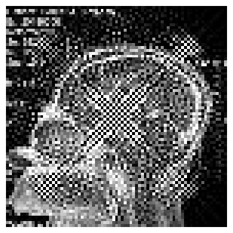

```python
beta_small = lsqr(X_small, y_small, atol=1e-5, btol=1e-5)[0].reshape(77, 77)

fig, ax = plt.subplots(figsize=(4, 4))
cax = ax.imshow(beta_small, vmin=0, vmax=255, interpolation='nearest', cmap='gray')
ax.axis('off')
fig.tight_layout()

plt.show()
```

Now we implement it from a larger version of the data.

```python
y_large = np.load('hs_tomography/y_195.npy')
alphas_large = np.load('hs_tomography/alphas_195.npy')
X_large = construct_X(195, alphas_large, 275).tocsc()

# Print shape and sparsity information
shape = f"Shape: {X_large.shape[0]} x {X_large.shape[1]}"
sparsity = f"Sparsity: {round(100 * (1 - X_large.nnz / np.prod(X_large.shape)), 2)} %"

print(f"{shape}\n{sparsity}\n")
```

```
Shape: 49225 x 38025
Sparsity: 99.28 %
```

[figure not shown]

```python
beta_large = lsqr(X_large, y_large, atol=1e-5, btol=1e-5)[0].reshape(195, 195)

fig, ax = plt.subplots(figsize=(4, 4))
cax = ax.imshow(beta_large, vmin=0, vmax=255, interpolation='nearest', cmap='gray')
ax.axis('off')
fig.tight_layout()

plt.show()
```

We can see that the image is getting much clearer now, and we can also see something like a small stick in H.S.'s brain. The treatment now should be removing the stick by surgery.

Comment

Both solutions are essentially the same.

### 3 Minimizing the radiation dose

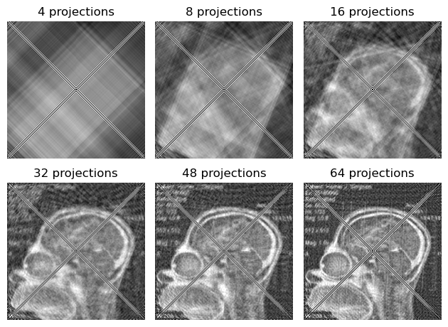

```python
Np = 275
y = np.load('hs_tomography/y_195.npy')
alphas = np.load('hs_tomography/alphas_195.npy')


projection_angles = [4, 8, 16, 32, 48, 64]
fig, axes = plt.subplots(2, 3)

for n, num_angles in enumerate(projection_angles):
    indices = [int(np.ceil(len(alphas) * p / num_angles)) for p in range(num_angles)]
    selected_alphas = alphas[indices]
    selected_responses = []


    for i in indices:
        selected_responses.extend(y[i*Np : (i+1)*Np])


    X = construct_X(195, selected_alphas, Np).tocsc()
    beta = lsqr(X, np.array(selected_responses), atol=1e-5, btol=1e-5)[0].reshape(195, 195)


    ax = axes.flat[n]
    ax.imshow(beta, vmin=0, vmax=255, interpolation='nearest')
    ax.set_title(f'{num_angles} projections')
    ax.axis('off')

plt.tight_layout()
plt.show()
```

Comment